# Prediction Assignment

Coursera Student

May 6, 2016

## Background

Using devices such as Jawbone Up, Nike FuelBand, and Fitbit it is now possible to collect a large amount of data about personal activity relatively inexpensively. These type of devices are part of the quantified self movement - a group of enthusiasts who take measurements about themselves regularly to improve their health, to find patterns in their behavior, or because they are tech geeks. One thing that people regularly do is quantify how much of a particular activity they do, but they rarely quantify how well they do it. In this project, your goal will be to use data from accelerometers on the belt, forearm, arm, and dumbell of 6 participants. They were asked to perform barbell lifts correctly and incorrectly in 5 different ways. More information is available from the website here: http://groupware.les.inf.puc-rio.br/har (see the section on the Weight Lifting Exercise Dataset).

## Data

The training data for this project are available here:

https://d396qusza40orc.cloudfront.net/predmachlearn/pml-training.csv

The test data are available here:

https://d396qusza40orc.cloudfront.net/predmachlearn/pml-testing.csv

The data for this project come from this source: http://groupware.les.inf.puc-rio.br/har.

## Objective

The goal of this project is to predict the manner in which they did the exercise as shown by the “classe” variable in the training set.

## Loading Data

```r
library(caret)
library(randomForest)
```

```r
library(rpart)
library(rpart.plot)
library(RColorBrewer)
library(rattle)
##Download Data
trainingDataSet <- read.csv(url("https://d396qusza40orc.cloudfront.net/predmachlearn/pml-training.csv"), na.strings=c("NA","#DIV/0!",""))
testDataSet <- read.csv(url("https://d396qusza40orc.cloudfront.net/predmachlearn/pml-testing.csv"), na.strings=c("NA","#DIV/0!",""))
```

## Cleaning and Partitioning Data

Let us clean the datasets by removing columns with a lot of NA and the first 7 variables.

```r
features <- names(testDataSet[,colSums(is.na(testDataSet)) == 0])[8:59]

# Only use features used in testing cases.
trainingDataSet <- trainingDataSet[,c(features,"classe")]
testDataSet <- testDataSet[,c(features,"problem_id")]
```

Here are the dimensions of the cleaned up training dataset

```r
dim(trainingDataSet);
```

```
## [1] 19622    53
```

Here are the dimensions of the cleaned up test dataset

```r
dim(testDataSet);
```

```
## [1] 20 53
```

Let’s partition the training dataset with 60% of test cases going in to training and the rest 40% in to testing.

```r
partition <- createDataPartition(y=trainingDataSet$classe, p=0.6, list=FALSE)
training1 <- trainingDataSet[partition, ];
testing1 <- trainingDataSet[-partition, ];
dim(training1);
```

```
## [1] 11776    53
```

```r
dim(testing1);
```

```
## [1] 7846   53
```

## Building Random Forest Model

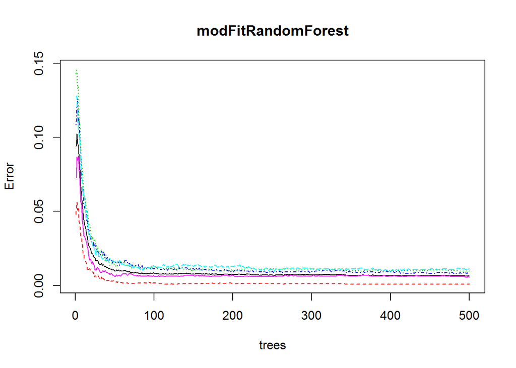

```r
set.seed(12345)

modFitRandomForest <- randomForest(classe ~ ., data = training1, method = "rf", importance = T, trControl = trainControl(method = "cv", classProbs=TRUE,savePredictions=TRUE,allowParallel=TRUE, number = 10))

plot(modFitRandomForest)
```

## Predicting with Random Forest Model

```r
prediction <- predict(modFitRandomForest, testing1, type = "class")
confusionMatrix(prediction, testing1$classe)
```

```
## Confusion Matrix and Statistics
##
##           Reference
## Prediction    A    B    C    D    E
##          A 2232   11    0    0    0
##          B    0 1503    7    0    3
##          C    0    4 1361   15    7
##          D    0    0    0 1271    4
##          E    0    0    0    0 1428
##
## Overall Statistics
##
##                Accuracy : 0.9935
##                  95% CI : (0.9915, 0.9952)
##     No Information Rate : 0.2845
##     P-Value [Acc > NIR] : < 2.2e-16
##
##                   Kappa : 0.9918
##  Mcnemar's Test P-Value : NA
##
## Statistics by Class:
##
##                      Class: A Class: B Class: C Class: D Class: E
## Sensitivity            1.0000   0.9901   0.9949   0.9883   0.9903
## Specificity            0.9980   0.9984   0.9960   0.9994   1.0000
## Pos Pred Value         0.9951   0.9934   0.9813   0.9969   1.0000
## Neg Pred Value         1.0000   0.9976   0.9989   0.9977   0.9978
## Prevalence             0.2845   0.1935   0.1744   0.1639   0.1838
## Detection Rate         0.2845   0.1916   0.1735   0.1620   0.1820
## Detection Prevalence   0.2859   0.1928   0.1768   0.1625   0.1820
## Balanced Accuracy      0.9990   0.9943   0.9954   0.9939   0.9951
```

You can see that the random forest model gave an excellent accuracy of 99.3%.

## Building Decision Tree Model

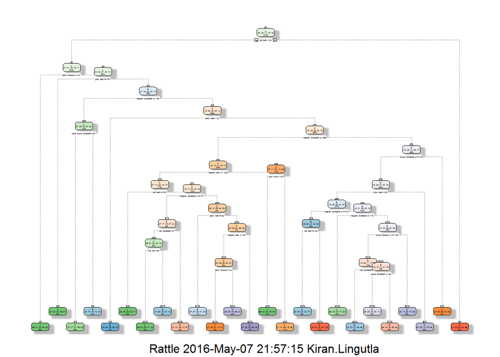

```r
set.seed(12345)
modFitDecisionTree <- rpart(classe ~ ., data = training1, method="class", control = rpart.control(method = "cv", number = 10))
fancyRpartPlot(modFitDecisionTree)
```

## Predicting with Decision Tree Model

```r
set.seed(12345)

prediction <- predict(modFitDecisionTree, testing1, type = "class")
confusionMatrix(prediction, testing1$classe)
```

```
## Confusion Matrix and Statistics
##
##           Reference
## Prediction    A    B    C    D    E
##          A 1960  232   15  129   61
##          B   92 1002   98   42   98
##          C   15  134 1022  185   93
##          D  121   74   87  863  108
##          E   44   76  146   67 1082
##
## Overall Statistics
##
##                Accuracy : 0.7557
##                  95% CI : (0.746, 0.7651)
##     No Information Rate : 0.2845
##     P-Value [Acc > NIR] : < 2.2e-16
##
##                   Kappa : 0.6902
##  Mcnemar's Test P-Value : < 2.2e-16
##
## Statistics by Class:
##
##                      Class: A Class: B Class: C Class: D Class: E
## Sensitivity            0.8781   0.6601   0.7471   0.6711   0.7503
## Specificity            0.9222   0.9479   0.9341   0.9405   0.9480
## Pos Pred Value         0.8177   0.7523   0.7053   0.6887   0.7647
## Neg Pred Value         0.9501   0.9208   0.9459   0.9358   0.9440
## Prevalence             0.2845   0.1935   0.1744   0.1639   0.1838
## Detection Rate         0.2498   0.1277   0.1303   0.1100   0.1379
## Detection Prevalence   0.3055   0.1698   0.1847   0.1597   0.1803
## Balanced Accuracy      0.9001   0.8040   0.8406   0.8058   0.8492
```

## Building Boosting Model

```r
modFitBoostModel <- train(classe ~ ., method = "gbm", data = training1,
                    verbose = F,
                    trControl = trainControl(method = "cv", number = 10))
modFitBoostModel
```

```
## Stochastic Gradient Boosting
##
## 11776 samples
##    52 predictor
##     5 classes: 'A', 'B', 'C', 'D', 'E'
##
## No pre-processing
## Resampling: Cross-Validated (10 fold)
## Summary of sample sizes: 10598, 10599, 10600, 10599, 10598, 10599, ...
## Resampling results across tuning parameters:
##
##   interaction.depth  n.trees  Accuracy   Kappa
##   1                   50      0.7537365  0.6879690
##   1                  100      0.8221825  0.7749419
##   1                  150      0.8541122  0.8154104
##   2                   50      0.8577616  0.8197431
##   2                  100      0.9067603  0.8820026
##   2                  150      0.9301117  0.9115594
##   3                   50      0.8961439  0.8685329
##   3                  100      0.9423413  0.9270393
##   3                  150      0.9613636  0.9511114
##
## Tuning parameter 'shrinkage' was held constant at a value of 0.1
##
## Tuning parameter 'n.minobsinnode' was held constant at a value of 10
## Accuracy was used to select the optimal model using  the largest value.
## The final values used for the model were n.trees = 150,
##  interaction.depth = 3, shrinkage = 0.1 and n.minobsinnode = 10.
```

## Predicting with Boosting Model

```r
prediction <- predict(modFitBoostModel, testing1)
confusionMatrix(prediction, testing1$classe)
```

```
## Confusion Matrix and Statistics
##
##           Reference
## Prediction    A    B    C    D    E
##          A 2198   48    0    2    4
##          B   23 1427   41    6   16
##          C    7   40 1313   43   20
##          D    3    3   13 1226   25
##          E    1    0    1    9 1377
##
## Overall Statistics
##
##                Accuracy : 0.9611
##                  95% CI : (0.9566, 0.9653)
##     No Information Rate : 0.2845
##     P-Value [Acc > NIR] : < 2.2e-16
##
##                   Kappa : 0.9508
##  Mcnemar's Test P-Value : 3.625e-12
##
## Statistics by Class:
##
##                      Class: A Class: B Class: C Class: D Class: E
## Sensitivity            0.9848   0.9401   0.9598   0.9533   0.9549
## Specificity            0.9904   0.9864   0.9830   0.9933   0.9983
## Pos Pred Value         0.9760   0.9432   0.9227   0.9654   0.9921
## Neg Pred Value         0.9939   0.9856   0.9914   0.9909   0.9899
## Prevalence             0.2845   0.1935   0.1744   0.1639   0.1838
## Detection Rate         0.2801   0.1819   0.1673   0.1563   0.1755
## Detection Prevalence   0.2870   0.1928   0.1814   0.1619   0.1769
## Balanced Accuracy      0.9876   0.9632   0.9714   0.9733   0.9766
```

## Conclusion

Out off the 3 models used for analysis, Random Forest Model proved to be the most accurate model for this training data. We will use the Random Forest Model on testing data.

## Predicting with Random Forest on Testing Data

```r
predictionRandomForest <- predict(modFitRandomForest, testDataSet)
predictionRandomForest
```

```
##  1  2  3  4  5  6  7  8  9 10 11 12 13 14 15 16 17 18 19 20
##  B  A  B  A  A  E  D  B  A  A  B  C  B  A  E  E  A  B  B  B
## Levels: A B C D E
```

## Submission

Here is the function to generate files with predictions using Random Forest Model for submission

```r
pml_write_files = function(x){
  n = length(x)
  for(i in 1:n){
    filename = paste0("problem_id_",i,".txt")
    write.table(x[i],file=filename,quote=FALSE,row.names=FALSE,col.names=FALSE)
  }
}

pml_write_files(predictionRandomForest)
```